# Assignment 4 Task 2

Tommy King

11/7/2021

### 0.0.1 Introduction:

This report provides data wrangling and visualizations to explore the relationships between juvenile snowshoe hares through capture-recapture studies at 5 locales in the Tanana Valley of Alaska. Specifically, this data examines the relationships found between snowshoe hare sex, hindfoot length, and location trapped to determine the relation and strength of these variables on hare weight at Bonanza Creek Experimental Forest. After conducting these investigations, we can conclude that there does exist a relationship between juvenile snowshoe hare weight and sex, as well as weight and hindfoot length. Namely, male hares had significantly larger mean weights over time from 1999 to present day than female hares, and hindfoot length was positively correlated with hare weight (without causation). The following visualizations depict these findings.

### 0.0.2 Data and Analyses:

Hare physical measurements were collected over time from 1999 to present day by Knut Kielland, Stuart F. Chapin, and Roger W Ruess in the Bonanza Creek Experimental Forest within 5 locales of the Tanana Valley, Alaska. The data contain observations for 378 juvenile snowshoe hares, captured since 1999. Following exploratory data visualization, weight (g) between male and female snowshoe hares are by two sample t-tests using a significance level of 0.05 throughout. Between-group differences are explored using Cohen’s *d* effect size. The relationship between hind foot length and weight is explored using simple linear regression.

# 1 Juvenile Hare Initial Investigation:

## 1.1 Annual Juvenile Hare Trap Counts

[figure not shown]

### 1.1.1 Annual Juvenile Trapped Snowshoe Takeaways:

Over the years from 1999 to 2012, there is a clear decline in the amount of hares trapped as depicted by our graph in Figure 1. Based on our descriptive data, the mean amount of hares trapped yearly was 32, however, that is significantly affected by our outliers in which the maximum trappings in one year was 126 while the minimum was 2. As a result, it is hard to gauge whether this data is a result of less time spent in the field, less traps set out in the field, or a decline in the juvenile Snowshoe Hare population. In order to standardize this process for future analyses, the amount of traps set and time spent in the field should be constant for every year, which will allow scientists to determine whether or not the juvenile hare population is declining more accurately.

# 2 Visualizing Juvenile Hare Weights

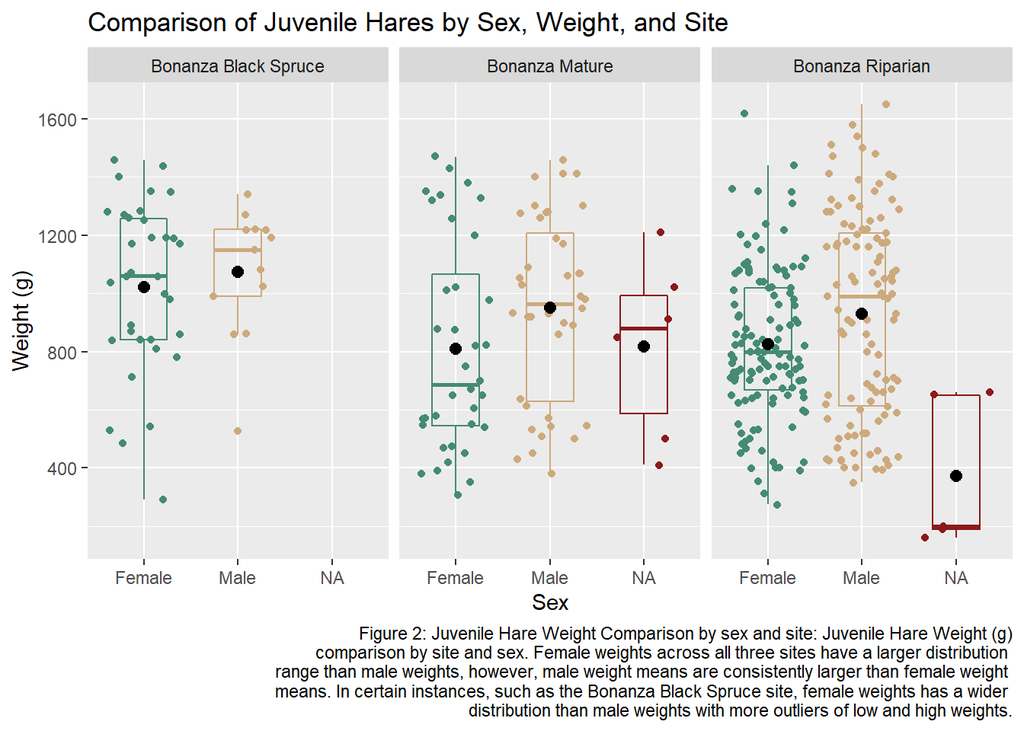

## 2.1 Main Takeaways from Visualization

# 3 Juvenile Weight Comparison (male and female snowshoe hares)

## 3.1 Data Table of Juvenile Weight Comparison

Table 1: Juvenile Snowshoe Hare Weight Comparison by Sex: Depiction of relevant data for comparing male and female snowshoe hare by weights. Includes data for mean weight for each group, standard deviation of weights, and sample size.

| Hare Sex | Mean Weight (g) | Standard Deviation Weight (g) | Sample Size |
| --- | --- | --- | --- |
| Female | 855 | 292 | 197 |
| Male | 946 | 333 | 163 |

On average, juvenile male snowshoe hares have a larger body mass than juvenile female snowshoe hares (945.86 $\pm$ 333.22 and 855.39 $\pm$ 292.25 grams, respectively; mean $\pm$ 1 standard deviation). While the absolute difference in means is 90.47 g (a 10.05% difference), the difference in means is significant (with a small magnitude) (Welch’s two-sample t-test: t(325.02) = 2.71, p < 0.05), and the effect size is small due to (Cohen’s *d* = 0.29). This indicates that further investigations would be needed to determine whether male snowshoe hares have an actually significant higher weight mean than females.

# 4 Relationship Between Juvenile Weight & Hind Foot Length

## 4.1 Visualizing the Relationship

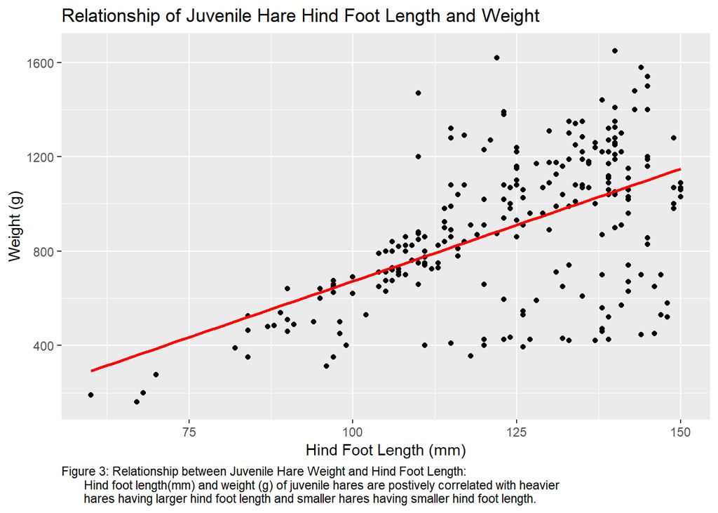

# 5 Final Summary:

Next steps:

- Repeat findings with further emphasis on consistency of data collection to determine accuracy of all findings
- Include multiple linear regressions to determine relationship between all statistical values collected

### 5.0.1 Citations:

Kielland, K., F.S. Chapin, R.W. Ruess, and Bonanza Creek LTER. 2017. Snowshoe hare physical data in Bonanza Creek Experimental Forest: 1999-Present ver 22. Environmental Data Initiative. https://doi.org/10.6073/pasta/03dce4856d79b91557d8e6ce2cbcdc14 (Accessed 2021-11-10).